# Practiceset2

**Question:** Calculate the mean of the following series: 27, 35, 42, 28, 68.

**Solution:** The **mean** (or average) is calculated using the formula:

$$\text{Mean} =
\frac{\text{Sum~of~all~values}}{\text{Number~of~values}}$$

Step 1: Sum of the values:

$$27 + 35 + 42 + 28 + 68 =
200$$

Step 2: Number of values = 5 (since there are 5 numbers in the series).

Step 3: Calculate the mean:

$$\text{Mean} = \frac{200}{5} =
40$$

So, the **mean** of the series is **40**.

**Question:**

Using the following data points, create a scatter plot:

X Values: 1, 2, 3, 4, 5

Y Values: 3, 6, 9, 12, 15

Plot the given data points on a scatter plot.

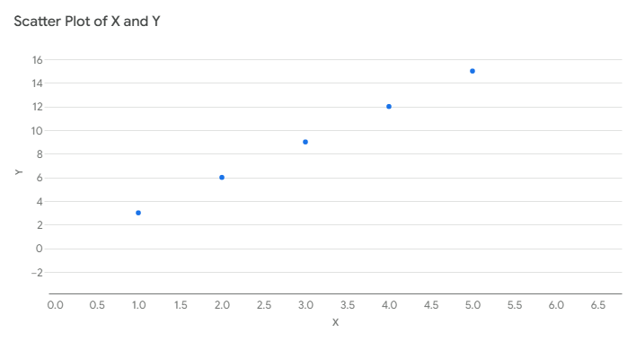

**Question:** Explain regression, and state how it is used in data analysis?

**Explanation:**

**Regression** is a statistical technique used to model and analyze the relationship between a dependent variable and one independent variable. The goal is to understand how the dependent variable changes as the independent variable changes. In simple terms, it allows us to predict the value of one variable based on the value of another.

### Simple Linear Regression:

In **simple linear regression**, there is one independent variable (X) and one dependent variable (Y). The relationship is modeled using a straight line, represented by the equation:

$$Y = a + bX$$

- **a** is the intercept (value of Y when X = 0).
- **b** is the slope (change in Y for a unit change in X).

This technique is used when you want to predict or understand the relationship between two variables.

### How Regression is Used in Data Analysis:

1. **Prediction:** Regression models are widely used for prediction. For example, in business, it can predict future sales based on advertising expenditure, or in finance to predict stock prices based on market trends.
2. **Trend Analysis:** Regression helps in understanding trends over time. For instance, in economics, it can be used to study the relationship between GDP and unemployment over several years.
3. **Quantifying Relationships:** It helps quantify the strength of the relationship between variables. For example, it can help determine how strongly variables like education level, age, and income are related to a person’s spending behavior.
4. **Risk Management:** In sectors like insurance or finance, regression models are used to assess risks and estimate the probability of certain outcomes, such as the likelihood of a claim being made based on various factors.
5. **Identifying Key Variables:** Regression analysis helps to identify which variables are most significant in influencing the outcome. For instance, determining which factors (e.g., marketing, customer satisfaction) most significantly affect customer retention.

### Example in Real-Life Data Analysis:

- **Marketing Campaign:** A company may use regression analysis to examine how sales (dependent variable) are influenced by factors like advertising spend, product price, and seasonality (independent variables). By doing this, the company can understand the effect of each factor and optimize its marketing strategy.

### Conclusion:

Regression is a powerful tool in data analysis used for prediction, understanding relationships, and making informed decisions. It helps in finding patterns in data, quantifying how variables interact, and making predictions based on those relationships.

**Question:** Calculate the probability that a digit selected from the digits 1, 2, 3, 4, 5, 6 is even.

**Solution:** The total set of digits is:

$$\{ 1,2,3,4,5,6\}$$

The **even digits** in this set are:

$$\{ 2,4,6\}$$

Step 1: Total number of possible outcomes = 6 (since there are 6 digits in the set). Step 2: Number of favorable outcomes (even digits) = 3 (the digits 2, 4, and 6).

Step 3: The probability is calculated as:

$$\text{Probability} =
\frac{\text{Number~of~favorable~outcomes}}{\text{Total~number~of~outcomes}}
= \frac{3}{6} = \frac{1}{2}$$

Thus, the probability that a randomly selected digit is even is **1/2**.

**Q. Explain Mutually Exclusive Events.**

**Mutually Exclusive Events** are events that **cannot happen at the same time**.

### Simple Examples:

1. **Rainy Day and Dry Day:** If you're checking the weather, it can either be a **rainy day** or a **dry day**. These two events are mutually exclusive because it cannot be both rainy and dry on the same day. If it’s raining, it’s not dry, and if it’s dry, it’s not raining.
2. **Odd Number and Even Number:** If you choose a number, it can either be **odd** or **even**, but not both at the same time. For example, 3 is odd, and 4 is even. These two events are mutually exclusive because you can't pick a number that is both odd and even.
3. **Heads and Tails on a Coin Toss:** When you flip a coin, it can either land on **Heads** or **Tails**, but not both at the same time. These events are mutually exclusive because you can't get both Heads and Tails in a single toss.

### Key Point:

If two events are mutually exclusive, it means that if one happens, the other cannot happen at the same time. Mathematically, this is represented as:

$$A \cap B = \varnothing$$

This means the **intersection** of events **A** and **B** is the **empty set**, indicating that there are no outcomes that belong to both events.

The **probability** of both events happening together is:

$$P(A \cap B) = 0$$

This means the probability that both events occur simultaneously is **zero** because they cannot happen together.

Question: Classify the various types of kurtosis.  
Kurtosis is a measure that tells us about the shape of a data distribution, specifically how **peaked** or **flat** it is compared to a normal distribution.

There are **three types** of kurtosis:

1. **Leptokurtic (High Kurtosis):**
   - The distribution has a **sharp peak** and **heavy tails** (more extreme values or outliers).
2. **Mesokurtic (Normal Kurtosis):**
   - This is a **normal distribution**, like the standard bell curve, with a **moderate peak** and **normal tails**.
3. **Platykurtic (Low Kurtosis):**
   - The distribution has a **flatter peak** and **lighter tails** (fewer extreme values or outliers).

In short:

- **Leptokurtic**: Sharp peak, heavy tails.
- **Mesokurtic**: Normal bell curve.
- **Platykurtic**: Flat peak, light tails.

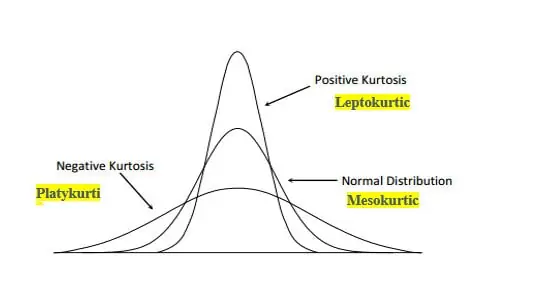

**Question:**

Using the following data points, create a scatter plot and analyze the correlation:

X Values: 1, 2, 3, 4

Y Values: 2, 4, 6, 8

1. Plot the given data points on a scatter plot.

2. Based on your observation, describe the type of correlation present in the data.

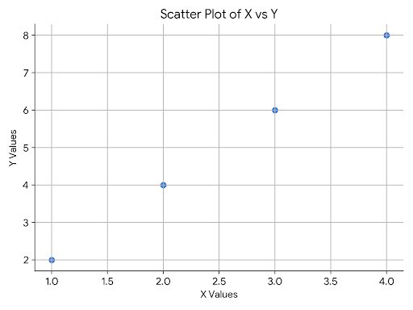

Here's the analysis of the data and the scatter plot:

**Scatter Plot Analysis**

- The scatter plot shows a perfect linear relationship between X and Y.
- As X increases, Y increases proportionally.
- The points form a straight line, indicating a strong positive correlation.

**Correlation Analysis**

- The correlation coefficient is 1.0, which confirms the perfect positive linear relationship.
- A correlation coefficient of 1 indicates that the data points fall exactly on a straight line with a positive slope.

In summary, there is a perfect positive correlation between the X and Y values.

**Solution:**

The formula to calculate the correlation coefficient $r$ is:

$$r = \sqrt{b_{xy} \times
b_{yx}}$$

$$r = \sqrt{0.9 \times 0.4} = \sqrt{0.36}
= 0.6$$

Since both $b_{xy}$ and $b_{yx}$ are positive, the correlation coefficient $r$ will also be positive. We reject the negative value ($r = - 0.6$) because correlation is inherently positive in this case. Therefore, the correlation coefficient $r$ is **0.6**.

**Question:** What is the probability of selecting an odd number from the digits 1, 2, 3, 4, 5, 6?

The digits you have are 1, 2, 3, 4, 5, and 6.

The odd numbers among these are 1, 3, and 5.

So, there are **3 odd numbers** out of a total of **6 numbers**.

The probability of selecting an odd number is given by:

$$\text{Probability} =
\frac{\text{Number~of~odd~numbers}}{\text{Total~number~of~numbers}} =
\frac{3}{6} = \frac{1}{2}$$

Thus, the probability of selecting an odd number is $\frac{1}{2}$ or 50%.

**Question:** What are independent events in probability?

Independent events in probability are events that **do not affect each other**. This means that the outcome of one event has **no impact** on the outcome of another event.

### Simple Explanation:

When two events are independent, knowing the result of one event doesn't change the probability of the other event.

### Example 1: Tossing a Coin

Let’s say you toss a coin twice.

- The first toss could result in heads or tails, and the second toss could also result in heads or tails.
- The outcome of the first toss (whether it’s heads or tails) **does not affect** the outcome of the second toss.
- So, the two tosses are **independent events**.

### Example 2: Rolling a Die

Let’s say you roll a six-sided die two times.

- The result of the first roll (whether you roll a 1, 2, 3, 4, 5, or 6) **does not affect** the result of the second roll.
- Each roll is independent of the other, so these are **independent events**.

### Why are these independent?

- The outcome of the first event (e.g., first coin toss or first die roll) does not change the probabilities of the second event (e.g., second coin toss or second die roll).

In simple terms: **Independent events are like two separate games happening at the same time. What happens in one game has no effect on the other.**

For two independent events A and B, the probability that both events happen (i.e., the intersection of A and B) is given by the formula:

P(A∩B) = P(A)×P(B)

**Question:** Classify the various measures of dispersion.

Measures of dispersion describe the **spread or variability** of a data set — essentially how much the data values differ from each other. They are critical in statistics to understand how data is distributed around a central value (like the mean or median).

Below is a classification and explanation of **common measures of dispersion**:

### **1. Range**

- **Definition**: The **simplest measure of dispersion**, calculated as the difference between the largest and smallest values in a dataset.
- **Formula**:

$$\text{Range} = \text{Maximum~value} -
\text{Minimum~value}$$

- **Use**: Gives a quick sense of how spread out the data is, but is **very sensitive to outliers**.

### **2. Coefficient of Range**

- **Definition**: A **relative measure of dispersion** that compares the range to the sum of the maximum and minimum values.
- **Formula**:

$$\text{Coefficient~of~Range} =
\frac{\text{Maximum} - \text{Minimum}}{\text{Maximum} +
\text{Minimum}}$$

- **Use**: Useful for comparing variability between datasets with different units or scales.

### **3. Interquartile Range (IQR)**

- **Definition**: The **range of the middle 50% of the data**, calculated as the difference between the third quartile (Q3) and the first quartile (Q1).
- **Formula**:

$$\text{IQR} = Q3 - Q1$$

- **Use**: Less affected by outliers; provides a **robust measure** of spread.

### **4. Mean Deviation (Average Absolute Deviation)**

- **Definition**: The **average of the absolute differences** between each data point and a central value (usually the mean or median).
- **Formula (from mean)**:

$$\text{Mean~Deviation} = \frac{\sum \mid
x_{i} - \overset{ˉ}{x} \mid}{n}$$

- **Use**: Indicates the **average distance from the mean**, but not commonly used in statistical theory due to its lack of mathematical tractability.

### **5. Standard Deviation (SD)**

- **Definition**: The **square root of the average squared deviation** from the mean. It shows how much the values deviate, on average, from the mean.
- **Formula**:

$$\text{SD} = \sqrt{\frac{\sum\left( x_{i}
- \overset{ˉ}{x} \right)^{2}}{n}}\quad$$

- **Use**: Most **commonly used measure** of dispersion; critical in inferential statistics.

### **6. Variance**

- **Definition**: The **square of the standard deviation**, representing the average squared deviation from the mean.
- **Formula**:

$$\text{Variance} = \frac{\sum\left( x_{i}
- \overset{ˉ}{x} \right)^{2}}{n}\quad$$

### **7. Coefficient of Variation (CV)**

- **Definition**: A **relative measure** of dispersion that expresses the standard deviation as a percentage of the mean.
- **Formula**:

$$\text{CV} = \left(
\frac{\text{Standard~Deviation}}{\text{Mean}} \right) \times
100$$

- **Use**: Useful for comparing variability **between datasets with different units or widely different means**.

**Question:** Predict the mean of the first 10 natural numbers: 1, 2, 3, 4, 5, 6, 7, 8, 9, 10.

To calculate the **mean** (average) of the first 10 natural numbers:

### Step 1: Add the numbers

$$1 + 2 + 3 + \cdots + 10 = \frac{10
\times (10 + 1)}{2} = \frac{10 \times 11}{2} = 55$$

### Step 2: Divide by the total number of values

$$\text{Mean} = \frac{55}{10} =
5.5$$

### ✅ Answer:

**The mean is 5.5**

**Question:** What does a correlation coefficient of 1 indicate?

a) No correlation

b) A perfect positive correlation

c) A perfect negative correlation

d) A strong positive correlation

**Correct Answer:** **b) A perfect positive correlation**

**Explanation:** The correlation coefficient, usually denoted as **r**, measures the strength and direction of a linear relationship between two variables. Its value ranges from **-1 to +1**:

- **r = 1** indicates a **perfect positive correlation**, meaning that as one variable increases, the other variable increases **in exact proportion**. All the data points lie exactly on a straight line with a positive slope.
- **r = -1** indicates a **perfect negative correlation**, meaning that as one variable increases, the other decreases in exact proportion.
- **r = 0** suggests **no linear correlation** between the variables.
- Values between 0 and ±1 indicate varying strengths of correlation.

Therefore, a correlation coefficient of **1** is the strongest possible **positive linear relationship** between two variables.

**Question:** What is the range of possible values for Karl Pearson's coefficient of correlation (r)? a) -1 to 1

b) 0 to 1

c) -∞ to ∞

d) 1 to ∞

**Correct Answer:** **a) -1 to 1**

**Explanation:** Karl Pearson’s coefficient of correlation (**r**) is a statistical measure that calculates the strength and direction of the linear relationship between two quantitative variables.

- The value of **r** always lies between **-1 and 1**, inclusive.
  - **r = 1** implies a **perfect positive linear relationship**.
  - **r = -1** implies a **perfect negative linear relationship**.
  - **r = 0** implies **no linear relationship** between the variables.

Any value outside this range (like greater than 1 or less than -1) is **not possible** for Pearson’s correlation coefficient.

**Question:** In a simple linear regression equation, $Y = a + bX$, what does **b** represent?

a) The intercept

b) The correlation coefficient

c) The slope of the line

d) The dependent variable

**Correct Answer:** **c) The slope of the line**

**Explanation:** In the simple linear regression equation $Y = a + bX$:

- $Y$ is the **dependent variable** (the outcome we are predicting),
- $X$ is the **independent variable** (the predictor),
- $a$ is the **intercept**, which is the value of $Y$ when $X = 0$,
- $b$ is the **slope of the line**, which tells us how much $Y$ changes for a **one-unit increase in** $X$.

So, **b** quantifies the rate of change of the dependent variable with respect to the independent variable — it's the key measure of the linear relationship between $X$ and $Y$ in the regression model.

**Question:** If you toss three fair coins, how many different results can you get?

a) 4

b) 6

c) 8

d) 10

**Correct Answer:** **c) 8**

**Explanation:** Each fair coin has **2 possible outcomes**: Heads (H) or Tails (T).

When tossing **three coins**, the total number of different possible outcomes is calculated using the multiplication rule:

$$2 \times 2 \times 2 = 8$$

So, the 8 possible results are:

- HHH
- HHT
- HTH
- HTT
- THH
- THT
- TTH
- TTT

Each combination is a unique result of the three coin tosses.

**Question:** A bag has 10 black balls and 20 white balls. If you pick one ball at random, what is the chance that it is white?

a) 1

b) 1/3

c) 2/3

d) 0

**Correct Answer:** **c) 2/3**

**Explanation:** To find the probability of picking a white ball, use the formula:

$$\text{Probability} =
\frac{\text{Number~of~favorable~outcomes}}{\text{Total~number~of~outcomes}}$$

- Number of white balls (favorable outcomes) = 20
- Total number of balls = 10 (black) + 20 (white) = 30

$$\text{Probability~of~white~ball} =
\frac{20}{30} = \frac{2}{3}$$

So, the chance of randomly selecting a white ball is **2/3**.

**Question:** What do we call the set of all possible outcomes of an experiment?

a) Combination

b) Sample point

c) Sample space

d) Compound event

**Correct Answer:** **c) Sample space**

**Explanation:** In probability theory:

- A **sample point** is a **single outcome** of an experiment.
- A **sample space** is the **set of all possible outcomes** of an experiment.
- A **combination** refers to a selection of items without regard to order.
- A **compound event** consists of **two or more simple events**.

For example, in tossing a coin once, the sample space is:

$$S = \{ H,T\}$$

Here, **H** and **T** are sample points, and the whole set $\{ H,T\}$ is the **sample space**.

**Question:** What is the probability of a certain event (an event that is guaranteed to happen)?

a) 0

b) 1

c) 0.5

d) 0.2

**Correct Answer:** **b) 1**

**Explanation:** The probability of an event ranges from **0 to 1**:

- A probability of **0** means the event will **never happen** (impossible event).
- A probability of **1** means the event is **certain to happen** (guaranteed event).
- Probabilities between 0 and 1 indicate varying levels of likelihood for the event to occur.

So, the probability of a **certain event** is always **1**.

**Question:** What does a correlation coefficient of 0 indicate?

a) A perfect positive correlation.

b) A perfect negative correlation.

c) No correlation.

d) A strong positive correlation.

**Correct Answer:** **c) No correlation**

**Explanation:** The **correlation coefficient** ($r$) measures the strength and direction of a linear relationship between two variables:

- **r = 1** indicates a **perfect positive correlation**, meaning both variables increase together in exact proportion.
- **r = -1** indicates a **perfect negative correlation**, meaning as one variable increases, the other decreases in exact proportion.
- **r = 0** indicates **no linear correlation** between the variables, meaning there is no predictable relationship in terms of a straight-line fit.
- Values between 0 and ±1 represent varying degrees of correlation (positive or negative).

Therefore, a correlation coefficient of **0** means there is **no linear relationship** between the two variables.

**Question:** Identify the primary difference between simple correlation and multiple correlation.

a) Simple correlation involves only two variables, while multiple correlation involves more than two variables.

b) Simple correlation is used to measure the strength of a linear relationship, while multiple correlation is used to measure the strength of a non-linear relationship.

c) Simple correlation is calculated using a single equation, while multiple correlation requires multiple equations.

d) Simple correlation is always positive, while multiple correlation can be positive or negative.

**Correct Answer:** **a) Simple correlation involves only two variables, while multiple correlation involves more than two variables.**

**Explanation:**

- **Simple correlation** refers to the relationship between **two variables**. It measures the strength and direction of a linear relationship between those two variables.
- **Multiple correlation** involves **three or more variables**. It is used to measure the strength of the relationship between one dependent variable and multiple independent variables.

So, the primary difference is that **simple correlation** deals with two variables, while **multiple correlation** considers more than two variables.

**Question:** In the regression equation $Y = a + bX$, what does **X** represent?

a) **X** is the independent variable.

b) The predicted value of **Y**.

c) A constant that never changes.

d) The total sum of all **Y** values.

**Correct Answer:** **a) X is the independent variable.**

**Explanation:** In the simple linear regression equation $Y = a + bX$:

- **Y** is the **dependent variable**, which we are trying to predict or explain.
- **a** is the **intercept** (the value of **Y** when **X = 0**).
- **b** is the **slope** of the regression line, representing how much **Y** changes for a one-unit change in **X**.
- **X** is the **independent variable** or predictor, which is used to predict the value of **Y**.

So, **X** is the independent variable in the equation.

**Question:** Which measure of central tendency represents the most frequent value in a dataset?

1. Mean
2. Median
3. Mode
4. Range

**Correct Answer:** **c) Mode**

**Explanation:** The **mode** is the measure of central tendency that represents the most frequent value in a dataset. It is the value that appears most often.

Here’s a quick overview of the other measures of central tendency:

- **Mean** is the average of all values in a dataset.
- **Median** is the middle value when the data is arranged in ascending or descending order.
- **Range** is the difference between the maximum and minimum values in the dataset.

So, **mode** is the correct answer because it identifies the most common or frequent value.

**Question:** If you toss two coins, what is the chance of getting at least one tail?

a) 1/4

b) 1/2

c) 3/4

d) 1

**Correct Answer:** **c) 3/4**

**Explanation:** When tossing two coins, the possible outcomes are:

- HH (both heads)
- HT (one head, one tail)
- TH (one tail, one head)
- TT (both tails)

Out of these 4 outcomes, **3 of them** (HT, TH, TT) have at least one tail. Only the outcome **HH** does not have a tail.

Thus, the probability of getting at least one tail is:

$$\frac{3}{4}$$

So, the chance of getting at least one tail is **3/4**.

**Question:** A bag contains 8 green balls and 12 yellow balls. What is the probability of picking a yellow ball?

a) 8/20

b) 12/20

c) 5/20

d) 10/20

**Correct Answer:** **b) 12/20**

**Explanation:** The total number of balls in the bag is:

$$8\text{~(green~balls)} +
12\text{~(yellow~balls)} = 20\text{~(total~balls)}$$

The number of yellow balls is **12**. So, the probability of picking a yellow ball is:

$$\frac{\text{Number~of~yellow~balls}}{\text{Total~number~of~balls}}
= \frac{12}{20} = \frac{3}{5}$$

Thus, the probability of picking a yellow ball is **12/20**.

**Question:** Which of the following represents the possible range of probability values?

a) -1 to +1

b) 0 to 1

c) 0 to n

d) 0 to ∞

**Correct Answer:** **b) 0 to 1**

**Explanation:** Probability values are always between **0 and 1**.

- **0** represents an impossible event (an event that will never occur).
- **1** represents a certain event (an event that is guaranteed to occur).
- Values between **0 and 1** represent varying levels of likelihood for an event happening.

Therefore, the range of probability values is **0 to 1**.

**Question:** What is the probability of an impossible event?

a) 0

b) 1

c) 0.5

d) 0.2

**Correct Answer:** **a) 0**

**Explanation:** The probability of an **impossible event** is **0**, meaning there is no chance that the event will occur. In probability theory:

- A probability of **0** indicates that the event cannot happen (it is impossible).
- A probability of **1** indicates that the event is certain to happen.

For example, if you were to roll a six-sided die and asked about the probability of rolling a 7, that would be an impossible event, and its probability would be **0**.

**Question:** Which measure of central tendency is the middle number in an ordered dataset?

a) Mean

b) Median

c) Mode

d) Range

The correct answer is:

**b) Median**

The **median** is the middle number in an ordered dataset. It divides the dataset into two equal halves.